# Reading and manipulating data frames

Load the tidyverse – just get used to doing it all the time. You’ll almost always need it.

```r
library(tidyverse)
```

## Introducing the data frame

You’ve seen values and vectors, but you haven’t seen a data frame yet. A data frame is an *object* in R, that is treated just like any other variable. However, it contains columns and rows, just like a spreadsheet.

Let’s start by importing a dataset of opioid emergency calls from Tempe, Arizona.

### Importing from a csv

This is a copy of a dataset that the city of Tempe used to have on its Open Government site: a list of emergency opioid-related calls. To read it, we’re using a package called *readr*, and the read_csv() command. This avoids some of the problems with recognizing data types that other importers have in R.

Try running this chunk, then looking up to the Environment area of your console. You should see an object called opiod_calls_orig, which you can click on to look inside.

```r
#the location on the Web for the data set's csv download

my_link <- "https://cronkitedata.github.io/cronkite-docs/assets/data/csv/opioidemscalls.csv"


#use it in a read_csv command

opioid_calls_orig <- read_csv(
         url(my_link)
         )
```

Look in your Environment tab. You’ll now see something in the area called Data, with an arrow next to it, telling you that opioid_calls_orig contains 650 observations (rows) and 21 variables (columns). Click on it to explore the data.

## The dplyr package and its verbs

Part of the tidyverse that we loaded earlier is called “dplyr” – I have no idea what it stands for, but we’ll be using it for most of our data frame work. There are several verbs that we’re going to go over today – actions that can be taken on a data frame.

Today, we’ll look at:

```
    select : Pick out columns.
    filter : Pick out rows.
    group_by : gather a variable into its values to make piles, i.e., putting together all of the clubs, hearts, spades and diamonds in a deck of cards.
    summarise : calculate a summary number like count or sum
    arrange: re-order the rows according to the value of variable ("sort" in Excel)
```

All but “select” have direct relationships to Excel pivot table

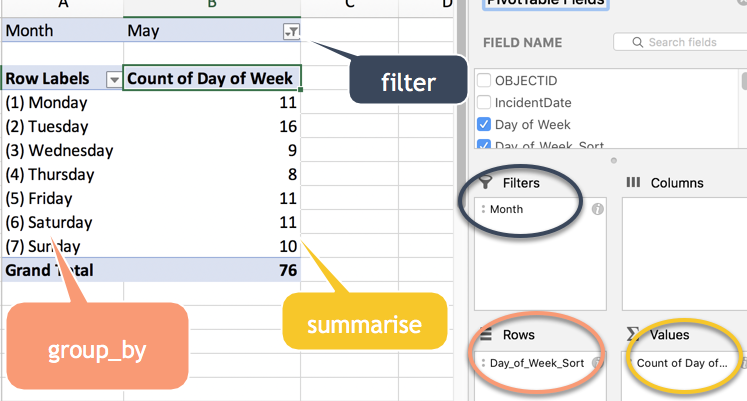

(sorting not shown here)

## select: copy and rename into a new data frame

Let’s clean this up a little to get some names that are easier to remember and don’t have odd characters. We can also choose not to include some in a new “data frame”.

The basic idea is to do the following:

1. Create a *new* data frame, with a new name by using the assignment operator, which is

   ```
      <- (think of it as "goes into")
   ```

2. Start with the name of an old data frame or source that you want to work from, followed by

   ```
    %>%   (think of this as "and then do the next thing")
   ```

3. **Select** is a basic verb in the tidyverse. It refers the columns you want to work with. You can choose them and rename them at the same time. You may have to put some of the old names in quotation marks if they have special characters or spaces in them.

R is **case-sensitive**, meaning that *age* is not the same thing as *Age*. Use an = sign to connect the new name (on the left) to the old name (on the right). Leave out the new name and the = sign if you want to use the old name.

You might note that I try to space out my commands and add whitespace where possible. The indentation is used to remind me what parts of the commands are connected to one another. But be careful - we’ve learned that the opening parenthese has to be on the same line as the verb.

```r
opioid_calls <-

     opioid_calls_orig  %>%

     select ( id = "OBJECTID",
             incident_date = "IncidentDate",
             dow = "Day_of_Week_Sort",
             impression = "Primary_Impression",
             narcan = "Narcan/Naloxone Given",
             age = Age,
             gender = Patient_Gender,
             asu_yn = Is_ASU_student,
             vet_yn = Is_Veteran,
             homeless_yn = Is_Homeles,
             special_population = Spec_Pop
     )
```

We now have two data frames in our Environment – the original and the new one.

## Displaying portions of the data frame

Let’s take a look at just a few of the lines using R commands. To do that, you’ll tell R which rows and columns you want. Here’s an example that takes the fields shown in the list, but only the 5th through 10th lines. (You always need to use a c() command – short for “combine” – when you need R to work on a list of items.)

The way you look at parts of a data frame is to identify the list of rows, then the list of columns within square brackets:

```
  name_of_df [  rows , columns]
```

```r
opioid_calls [
              5:10,                                    #rows 5 through 10
              c("id","narcan", "incident_date")        #the list of field names
        ]
```

| id | narcan | incident_date |
| --- | --- | --- |
| 6 | No | 1/9/2017 17:59 |
| 7 | Yes | 1/11/2017 11:10 |
| 8 | No | 1/12/2017 19:55 |
| 9 | No | 1/12/2017 22:02 |
| 10 | No | 1/14/2017 17:29 |
| 11 | Yes | 1/14/2017 22:51 |

## Choosing rows

**Filter** is the verb you use to choose which rows are included in your output. If “select” works on columns, “filter” works on rows.

```
    ==   equals
    >    Is more than
    <    Is less than
    %in%   Is in a list of values
    !=   does NOT equal
```

Connect them with logical operators, including:

```
    |    "Or" -- think of it as "this or that"
    &    "And"  -- both things must be true
```

**“==” isn’t “=” ! You always need two equals signs for comparison. A single = sign is used to assign something to another value.**

If you don’t assign the result to another variable, or to itself, it will just print out on the screen:

```r
opioid_calls %>%
  filter (
    narcan == "Yes"

  ) %>%

glimpse  # look at the output shown by variable, which shows the column names and one lines' worth of data
```

```
## Observations: 370
## Variables: 11
## $ id                 <dbl> 3, 7, 11, 12, 13, 18, 20, 21, 25, 29, 30, 34,…
## $ incident_date      <chr> "1/9/2017 1:08", "1/11/2017 11:10", "1/14/201…
## $ dow                <chr> "(1) Monday", "(3) Wednesday", "(6) Saturday"…
## $ impression         <chr> "ALOC (R41.82)", "ALOC (R41.82)", "ALOC (R41.…
## $ narcan             <chr> "Yes", "Yes", "Yes", "Yes", "Yes", "Yes", "Ye…
## $ age                <chr> "40 to 44", "80 to 84", "35 to 39", "40 to 44…
## $ gender             <chr> "Male", "Male", "Female", "Male", "Male", "Ma…
## $ asu_yn             <chr> "No", "No", "No", "No", "No", "Unknown", "No"…
## $ vet_yn             <chr> "No", "No", "No", "No", "No", "Unknown", "No"…
## $ homeless_yn        <chr> "No", "No", "No", "No", "No", "Unknown", "No"…
## $ special_population <chr> "No", "No", "No", "No", "No", "Unknown", "No"…
```

Let’s try a more complex one. This says, find me the rows that have narcan == “Yes” and also have asu_yn == “Yes”. In other words, cases in which ASU students were treated with Narcan.

```r
opioid_calls %>%
  filter (
    narcan == "Yes"  &  asu_yn == "Yes"
  )  %>%
  head()  # another way to preview your data
```

[output not shown]

## Stringing together commands

We can keep adding commands that work on the results of the previous one. In this example, we’ll filter for young men, then group them by the day of the week, then count up the number in each day, then sort those results in descending order.

### Group by and counting

In R, grouping and counting are done in different steps with different verbs. Think if **group_by** and **summarise** (British spelling) as a pivot table row or column element, and the summarise as the Value area of your pivot table. In this case, we’re grouping by *dow* (day of week), then counting the number of cases , using n().

At the same time, we want to sort the output by the highest number of cases to the lowest, which is done using the last verb for today, the *arrange* command.

```r
opioid_calls %>%
  #don't forget to put the %>% at the end when you want to keep going. You'll get a weird error without it.
  filter (  gender == "Male" &
            age %in% c("20 to 24", "15 to 19", "25 to 29")
          ) %>%

  #now group
  group_by (dow) %>%

  #now count
  summarise (case_ct = n() ) %>%

  #now reorder based on the count we just calculated
  arrange(desc(case_ct))
```

| dow | case_ct |
| --- | --- |
| (4) Thursday | 30 |
| (6) Saturday | 29 |
| (5) Friday | 27 |
| (1) Monday | 26 |
| (2) Tuesday | 25 |
| (3) Wednesday | 18 |
| (7) Sunday | 18 |

## Traps

### Case-sensitivity

R is always case-sensitive, which means that it makes a difference whether an object, a column name or the value of a variable (like Male) is upper-case, lower-case or some proper case. For example:

```
    filter (opioid_calls, narcan == "yes")
```

will result in 0 cases, because narcan is shown as “Yes”, not as “yes”. Instead, match the case to what you have in your data.

```r
filter (opioid_calls, narcan == "Yes") %>%
  summarize(n())  #just show me how many match
```

[output not shown]

One way to deal with this is to turn everything into lower case for the time you do your analysis. If you’re planning on working with something that isn’t consistent in casing, that’s the easiest thing to do in the long run. Another way is to use transformations to make sure:

```r
filter(opioid_calls, str_to_lower(narcan) == "yes") %>%
  head()
```

| id | incident_date | dow | impression | narcan | age | gender | asu_yn | vet_yn | homeless_yn | special_population |
| --- | --- | --- | --- | --- | --- | --- | --- | --- | --- | --- |
| 3 | 1/9/2017 1:08 | (1) Monday | ALOC (R41.82) | Yes | 40 to 44 | Male | No | No | No | No |
| 7 | 1/11/2017 11:10 | (3) Wednesday | ALOC (R41.82) | Yes | 80 to 84 | Male | No | No | No | No |
| 11 | 1/14/2017 22:51 | (6) Saturday | ALOC (R41.82) | Yes | 35 to 39 | Female | No | No | No | No |
| 12 | 1/15/2017 6:56 | (7) Sunday | Overdose- Intentional (T50.902A) | Yes | 40 to 44 | Male | No | No | No | No |
| 13 | 1/16/2017 15:54 | (1) Monday | ALOC (R41.82) | Yes | 30 to 34 | Male | No | No | No | No |
| 18 | 1/22/2017 6:36 | (7) Sunday | ALOC (R41.82) | Yes | 15 to 19 | Male | Unknown | Unknown | Unknown | Unknown |

Another way is to use what’s called “regular expressions” to extract the pieces you want. We’ll get into that later.

### Equals versus double-equals

You’ll get this weird error if you try to use an equals sign as a comparison operator:

```r
filter(opioid_calls, narcan = "Yes")
```

```
## `narcan` (`narcan = "Yes"`) must not be named, do you need `==`?
```

Note that R is guessing that you meant “==” instead. It won’t always be so kind.

### Forgetting the “and then” operator (%>%)

You also get a weird error if you forget to string together commands without the %>%. In this example, it prints the first list with the filter, then doesn’t know what to do with the group_by(dow) part, and says that it can’t find an object called “dow”. This is very common and hard to remember.

A code chunk that looks like this:

```
  filter (opioid_calls, narcan == "Yes")
      group_by (dow)
```

will result in the error that says,

```
  Error in group_by(dow) : object 'dow' not found
```

It doesn’t make much sense, except it’s telling you that it is no longer finding a field called *dow*. So it does the filter, gives you the results, then tries to run another command.

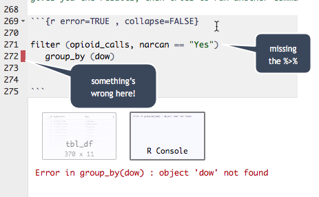

This is really common and a pain. R thought you had TWO things you wanted to do – one is just the filter, the other is an error. The fix is to put the %>% after the filter.

```r
filter (opioid_calls, narcan == "Yes") %>%
   group_by (dow) %>%
   summarize ( n())
```

| dow | n() |
| --- | --- |
| (1) Monday | 50 |
| (2) Tuesday | 46 |
| (3) Wednesday | 46 |
| (4) Thursday | 51 |
| (5) Friday | 61 |
| (6) Saturday | 60 |
| (7) Sunday | 56 |